# Red Wine Quality

Nicolas Arquie

July 21, 2017

I’m using the red wine dataset from Paulo Cortez (Univ. Minho), Antonio Cerdeira, Fernando Almeida, Telmo Matos and Jose Reis (CVRVV) @ 2009. The dataset includes quality of red wines based on experts’ tastes and some non-identifying qualities of the wines that help to show which aspects of red wines are correlated to a better quality of wine.

## Univariate Plots

Quality

```
##    Min. 1st Qu.  Median    Mean 3rd Qu.    Max.
##   3.000   5.000   6.000   5.636   6.000   8.000
```

A few details about quality of red wine as judged by wine experts.

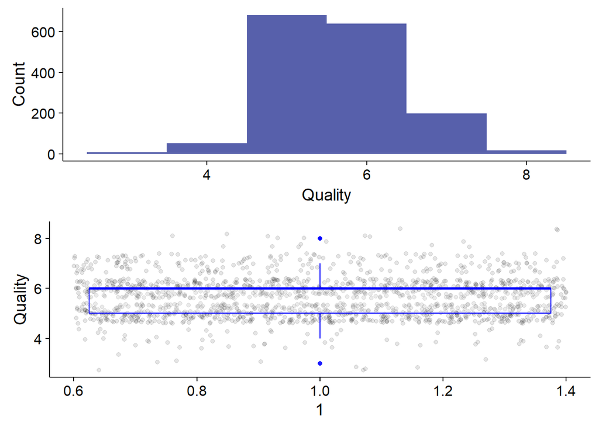

Quality seems to range between 5-7, not much in any other range. Seems like experts don’t rate any lower or higher… perhaps the wine quality is decent overall? Or the experts are hesitant to rate too low or too high? The boxplot also shows that ratings of 3 and 8 are rare, from which we could already see in the histogram.

Fixed Acidity

```
##    Min. 1st Qu.  Median    Mean 3rd Qu.    Max.
##    4.60    7.10    7.90    8.32    9.20   15.90
```

Stats on fixed acidity - the amount of overall acidity of the wine that is not volatile.

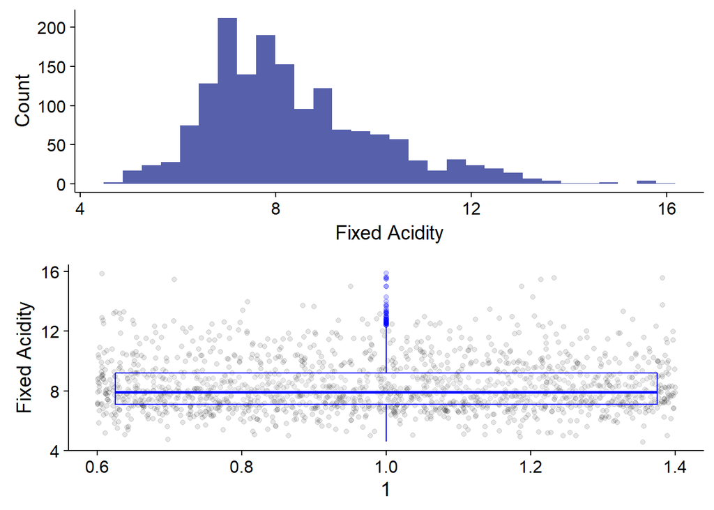

Fixed acidity ranges from around 7 g / dm^3 of tartaric acid to (at the highest) 13 g / dm^3 generally as a whole, with maximum at 16 g / dm^3 highest and possibly 6 g / dm^3 at the minimum. Tartaric acid is supposed to be correlated with the temperature of the location and it might not be too much of a supposition to think that perhaps the vineyards are placed in areas of the same climate on average.

Volatile Acidity

```
##    Min. 1st Qu.  Median    Mean 3rd Qu.    Max.
##  0.1200  0.3900  0.5200  0.5278  0.6400  1.5800
```

Stats for volatile acidity which relates to how much a wine tastes like vinegar.

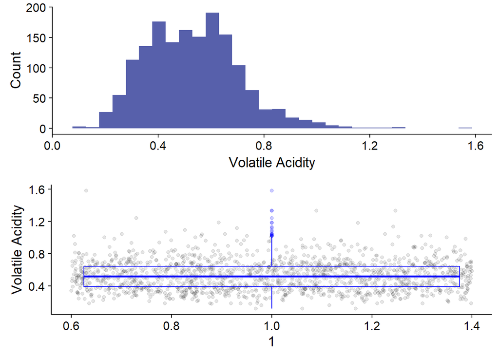

The range of volatile acid ranges in majority from around 0.4 g / dm^3 of acetic acid to around 0.8 g / dm^3 with the maximum range going as high as 1.6 g / dm^3. These ranges are caused by external issues such as exposure to “bugs” that can cause a higher concentration of volatile acidity. For the most part, it seems that these bugs are under control for a decent range of the red wines.

Citric Acid

```
##    Min. 1st Qu.  Median    Mean 3rd Qu.    Max.
##   0.000   0.090   0.260   0.271   0.420   1.000
```

The stats for citric acid, which is the main acid found in fruits such as oranges and lemons.

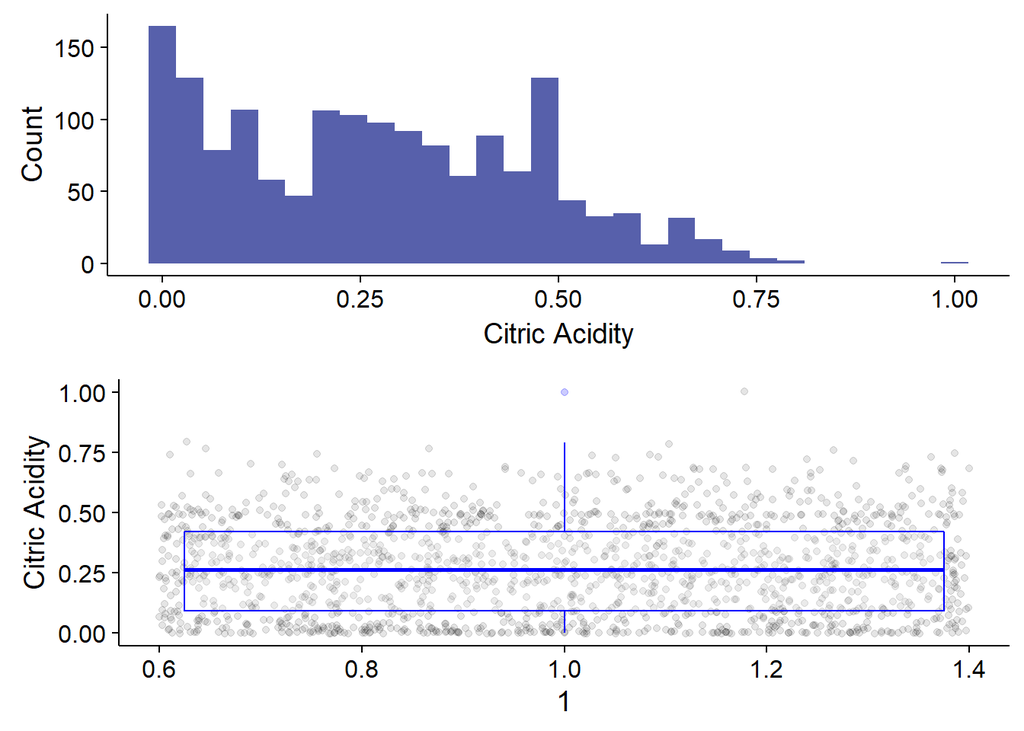

There seems to be more of a variance in citric acidity (ranges of 0.125 g / dm^3 to less than 0.5 g / dm^3) than in any of the other variables looked through so far. It is very possible that the range of berries used for these analyses could be varied enough to naturally cause this variation… which would seem probable as the wine experts must be testing quite a ranging degree of red wines and red wine types.

Chlorides

```
##    Min. 1st Qu.  Median    Mean 3rd Qu.    Max.
## 0.01200 0.07000 0.07900 0.08747 0.09000 0.61100
```

Stats of chloride, the amount of salt in the wine.

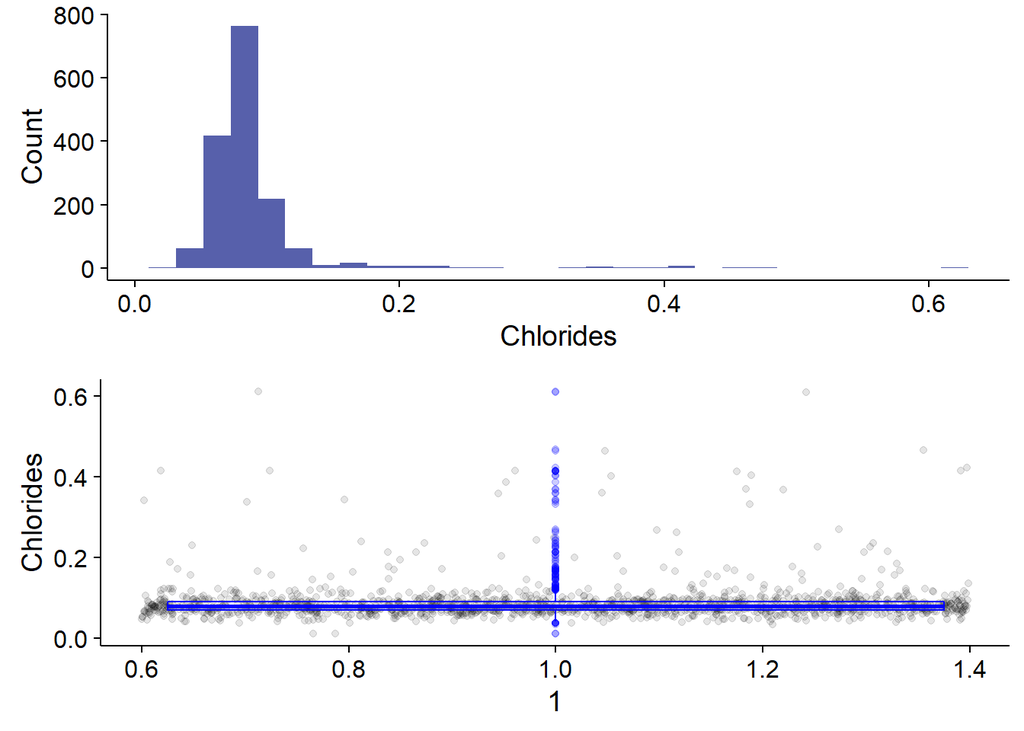

Seems that chloride (in the area of 0.1 g / dm^3 of sodium chloride) is very well restricted in the wines. This makes sense as the wine experts (and most of the consumers if they are exposed to the same wines as the experts) can very likely taste the salt in the wines, and can taste the variation in one wine as opposed to another which makes it critical to avoid large ranges in wine.

Total Sulfur Dioxide

```
##    Min. 1st Qu.  Median    Mean 3rd Qu.    Max.
##    6.00   22.00   38.00   46.47   62.00  289.00
```

Stats of total sulfur dioxide, which can have a pungent taste.

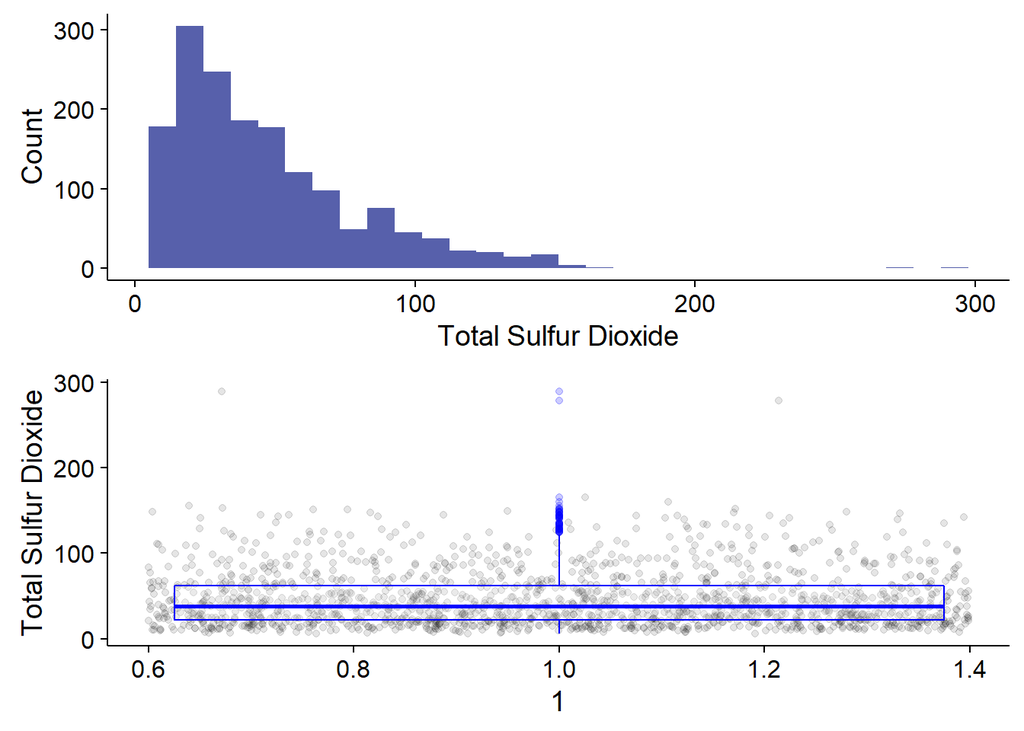

Sulfur dioxide is added to wines for protection against microbial agents and to allow the wine to age for longer periods of time. The lack of variation in the sulfur dioxide’s mg / dm^3 (ranging from below 10 mg / dm^3 to more than 100 mg / dm^3) does not seem to have much variance because of the necessary ranges in the wine that are needed to both keep positive effects while not causing adverse effects such as bad taste. There are a few points that are outliers on this graph that I have no explanation for… hopefully the majority of the points outweigh the few outliers that might skew relationships in the analyses to follow.

pH

```
##    Min. 1st Qu.  Median    Mean 3rd Qu.    Max.
##   2.740   3.210   3.310   3.311   3.400   4.010
```

Stats for pH which is how much like a “base” (opposite of an acid) a wine is. Most wines are acidic, which is why we see the max level is under 4 here (where 7 is neutral).

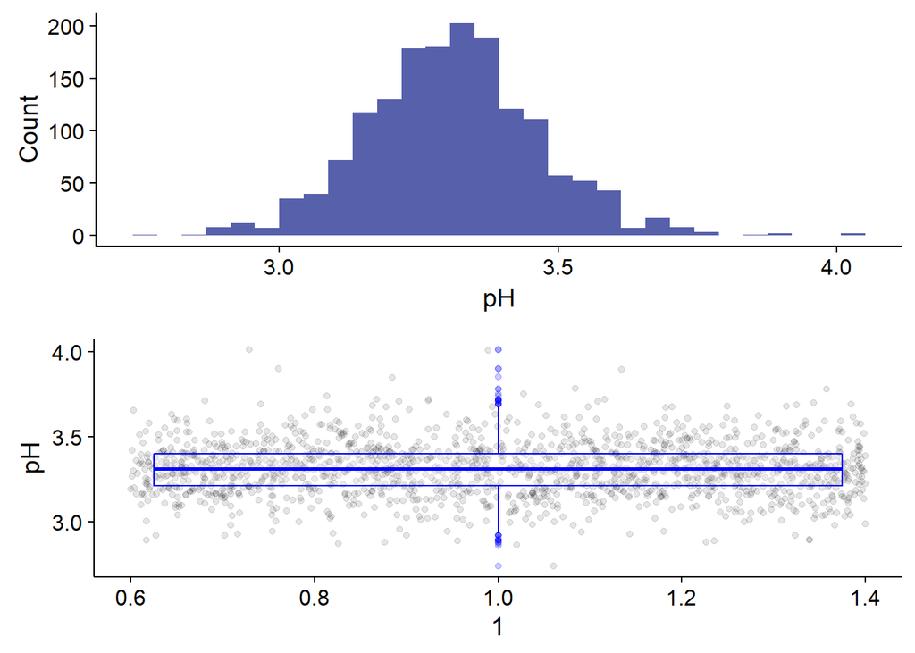

The pH ranges from between 3.0 to 3.5 which is not very surprising considering wine is primarily made of acids, which means it should range between values lower than 7.0. All the acids that are present in the wine (tartaric, acetic, citric…) all have pH below 4.0, so the 3.0 to 3.5 range of pH for these wines is not out of the ordinary.

Alcohol

```
##    Min. 1st Qu.  Median    Mean 3rd Qu.    Max.
##    8.40    9.50   10.20   10.42   11.10   14.90
```

Level of alcohol in percent by volume.

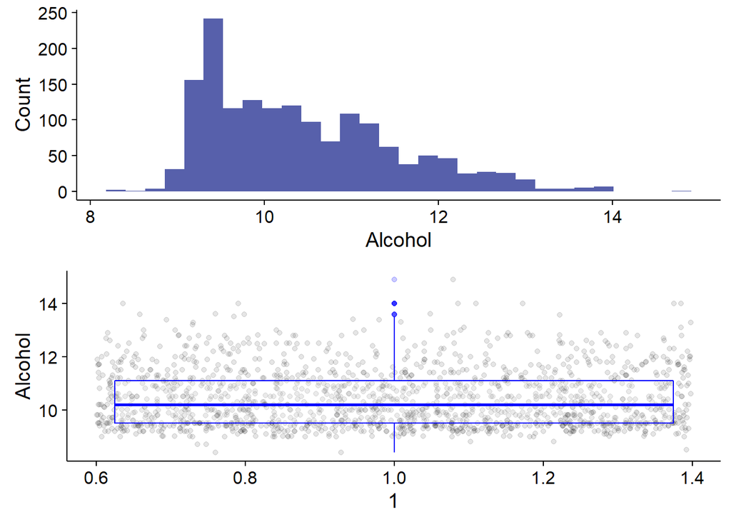

Wine, as it is not a spirit, should not have alcohol levels above 20% alcohol by volume as a sample heuristic. The values of around 8% alcohol by volume to 14% alcohol by volume is totally reasonable.

Sugar

```
##    Min. 1st Qu.  Median    Mean 3rd Qu.    Max.
##   0.900   1.900   2.200   2.539   2.600  15.500
```

Amount of sugar after fermentation stops.

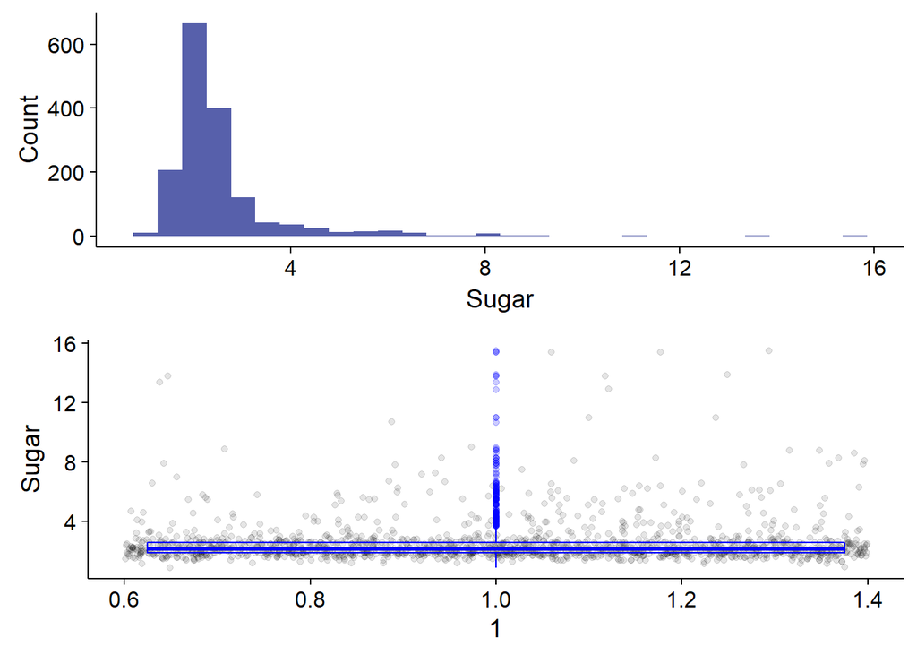

Sugar, measured in g / dm^3, seems to have quite a few outliers, perhaps because wines can have a varied array of sugars and certain states have limitations on how much sugar can be added post processing. There seems to be a few sweet wines out there in this dataset, which is odd as red wine usually doesn’t have as much sugar as rose or white wine.

### What is the structure of your dataset?

There are 1,599 wines in the dataset with 12 features (fixed.acidity, volatile.acidity, citric.acid, residual.sugar, chorides, free.sulfur.dioxide, total.sulfur.dioxide, density, pH, sulphates, alcohol, quality). All these variables are continuous except for quality which is a categorical variable from 0-10 (though only values 3-8 show up in the dataset).

### What is/are the main feature(s) of interest in your dataset?

The main feature in the dataset is the quality of the red wines. All of the rest of the exploratory analysis will be focused on this and the relationship between quality and the other variables.

### What other features in the dataset do you think will help support your investigation into your feature(s) of interest?

I’ll investigate this further with the correlation plot to follow. As it is, I skipped the residual sugar analysis because of its low correlation with quality, and I’ll follow up with the other variables that have a higher or lower correlation with quality to find out the approximate effect of the variables on red wine quality.

### Did you create any new variables from existing variables in the dataset?

I did not create any new variables from existing variables in the dataset. I will, however, be creating factors of existing variables to elaborate on various ranges of other variables in the dataset to create multivariate analyses.

## Bivariate Plots

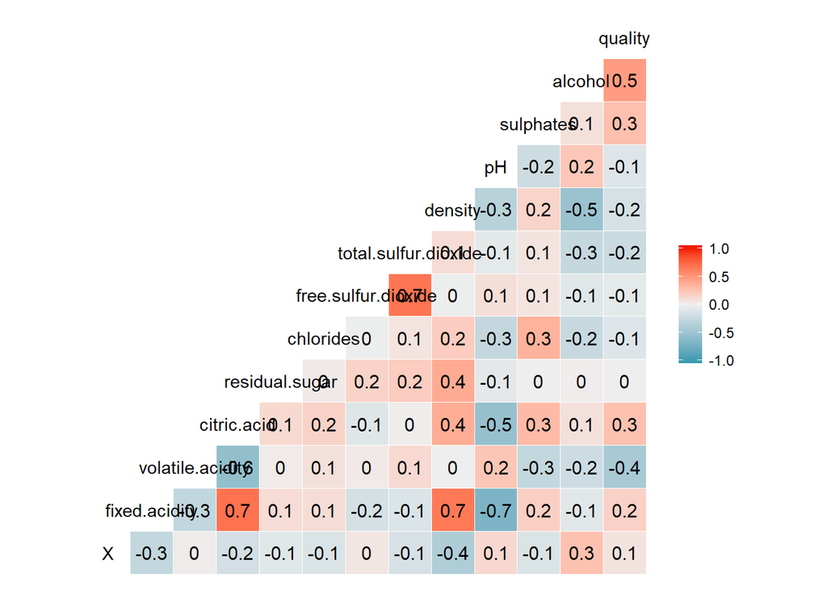

We are mostly concerned with the quality of the red wine, since the rest of the quantities are less easy to tell how they contribute to the taste - we can see that there is a positive correlation between quality / alcohol level, quality / citric acid level, and quality / fixed acidity. We can also tell that there is a negative correlation between quality / total sulfur level, quality / volatile acidity, and weak negative correlation between quality / pH and quality / chlorides

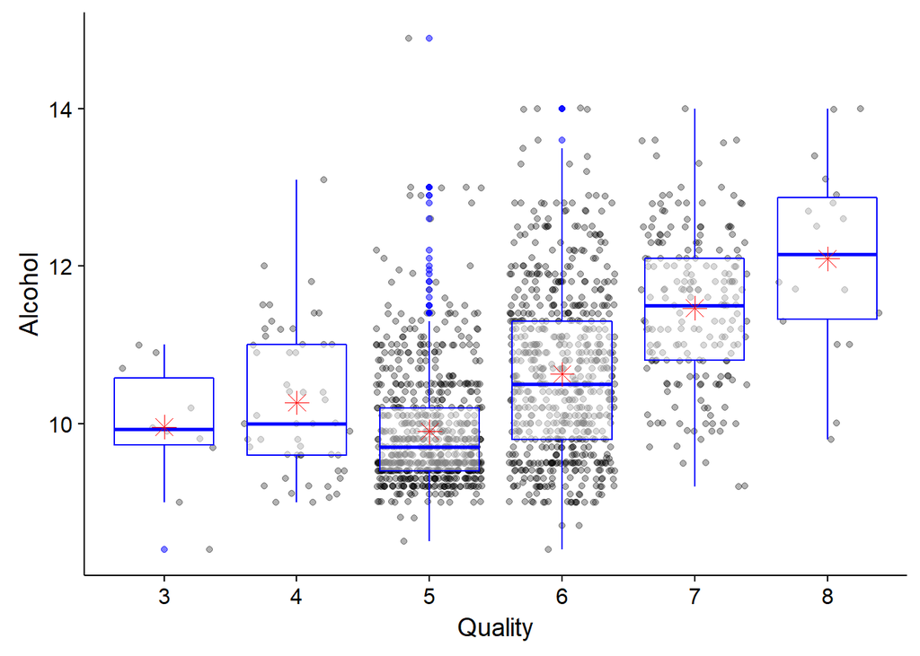

For the majority of the plot (quality of 5-7), we can see a strong positive correlation between alcohol content vs. quality. This shouldn’t catch us by surprise as the correlation between alcohol and quality is the highest of the pairings between quality and other variables. Interesting that wine experts would find higher quality in red wines with more alcohol - we can’t assume that alcohol creates this higher quality, but the amount of positive correlation is striking.

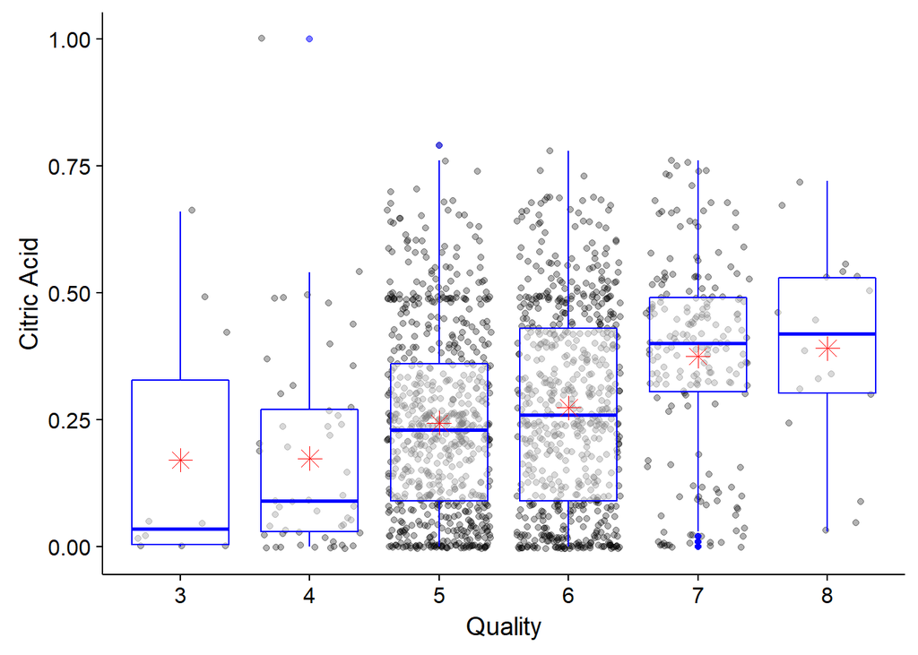

Though we should have been prepared for the positive correlation between quality and citric acid, it is still interesting to see how much of a correlation citric acid has with quality. Is it possible that experts have a liking for citric fruits, or is there something else hidden that is causing this relationship?

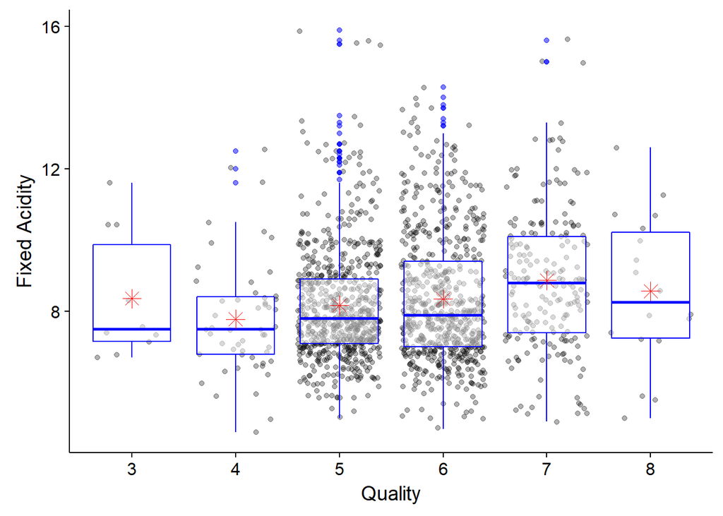

Positive correlation between fixed acidity and quality. Small positive correlation between fixed acidity and quality shows up here between values of 5-7 quality. Fixed acidity can add to the “tartness” of the wine which is the same role that citric acid plays in the wine. Seems that there might be a relationship between citric and fixed acidity that we could look into more.

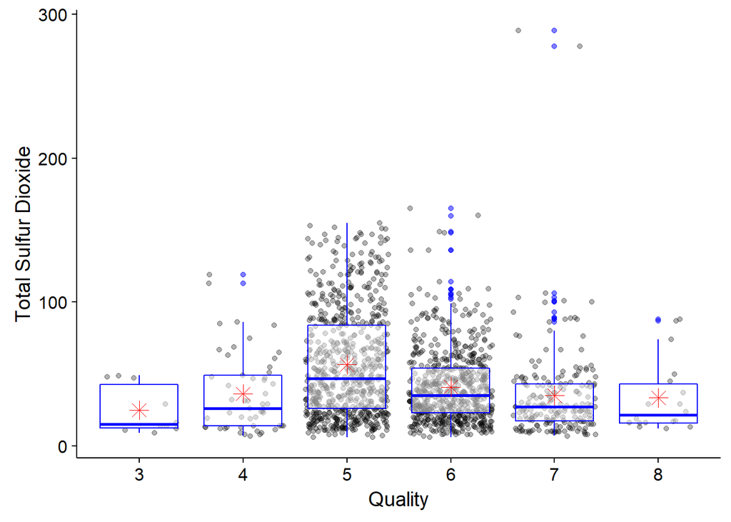

Not too much of a suprise here that total sulfur dioxide is correlated with lower values of quality… the bad taste of sulfur dioxide should be negatively correlated with quality and it shows up as such here.

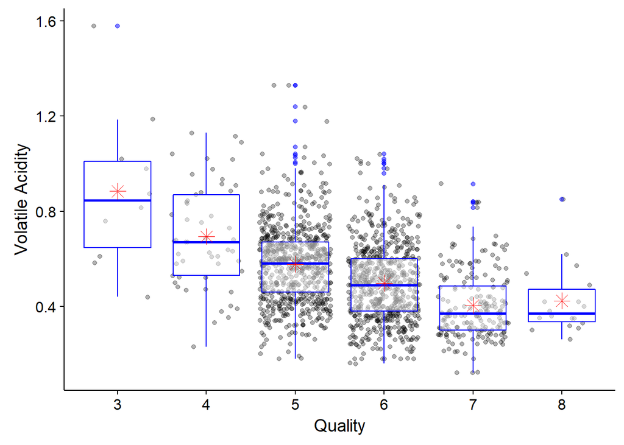

Volatile acidity is what makes the wine taste more like vinegar, so it is not too surprising to see it be negatively correlated with quality. Interesting but not too important that the values of quality 3 and 4 are also part of the negatively correlated aspect of volatile acidity in a graph where the 5’s, 6’s, and 7’s are a much more important part.

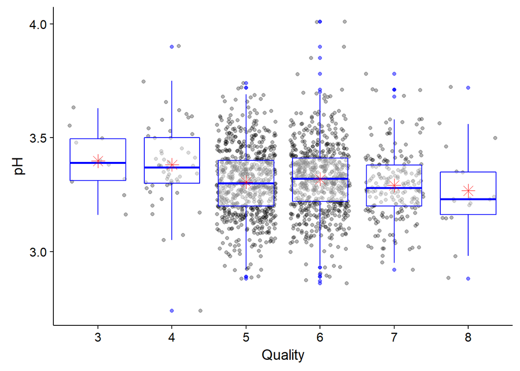

Not much correlation between pH and quality which could be expected, especially after noticing that its correlation metric is around 0. Seems that wine experts don’t have any way to detect how acidic a particular wine is, or that the acidity of the wine doesn’t matter to the taste, or some other hidden aspect.

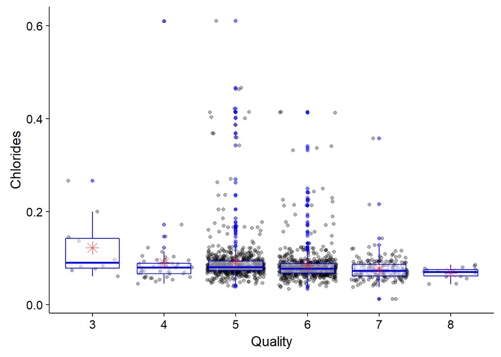

Chlorides, like pH, is not very negatively correlated with the quality of wine (though admittedly there is a small negative trend in quality with amount of chloride). This result is surprising to me as I would have thought that saltiness in wine would be a criteria to how bad / good the quality of the wine is. I guess that because the distribution of the chlorides is rather small (in the univariate analysis) there isn’t much difference between the saltiness in this collection of wines in the first place.

### Did you observe any interesting relationships between the other features (not the main feature(s) of interest)?

Citric acidity and fixed acidity might be interrelated, which I will go into more depth in multivariate to see if there is any relationship between these two and quality.

### What was the strongest relationship you found?

The strongest relationship I found was between alcohol and quality, where the correlation coefficient between the two is 0.5.

## Multivariate Plots

In these plots, we are trying to see the relationship between quality, alcohol, and different third variables so we can see if there is a joint correlation between the three. I am using alcohol by volume in these plots as compared to another variable because of the very strong correlation between the quality and alcohol.

I created a factored level of citric acid within the quantities of (0.2-0.3,0.3-0.4,0.4-0.5, and 0.5-0.6). I created this discrete variable to show distinct changes in the following graph through discrete, distinct values.

I also created factored levels for sulfur dioxide, volatile acid, fixed acidity, and chloride levels.

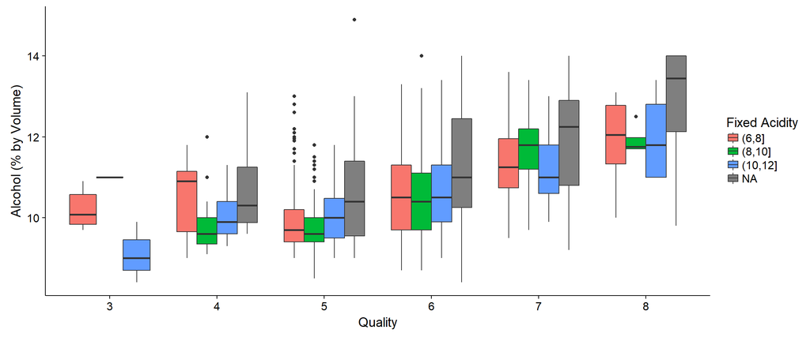

Not much of a relationship between fixed acidity and alcohol / quality. Though fixed acidity is only minorly correlated with both quality and alcohol, I would’ve thought that there would be a more visible relationship on the graph as a whole.

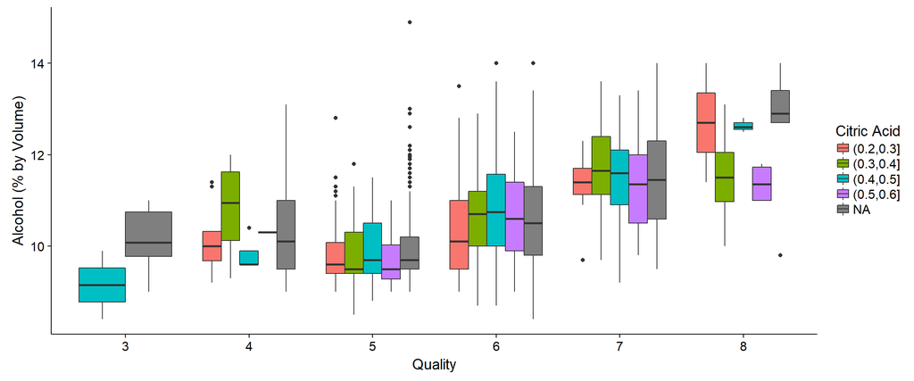

Not much indication of the positive correlation between citric acid and alcohol. The trends that are visible are not clear from one step up in quality and the relationship between alcohol and citric acid.

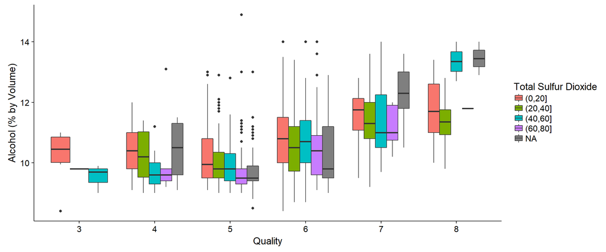

Weak relationship between alcohol, quality, and total sulfur dioxide. There is little representation that there is a negative relationship between total sulfur dioxide and alcohol / quality, but not enough to say for certain.

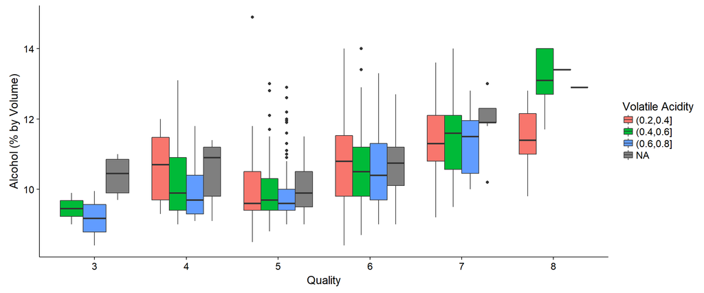

There is a bit of a negative trend that we can see on a quality of 6, but overall there is not much to be said between the relationship of alcohol and volatile acidity to be able to make reasonable guesses about the interaction between variables.

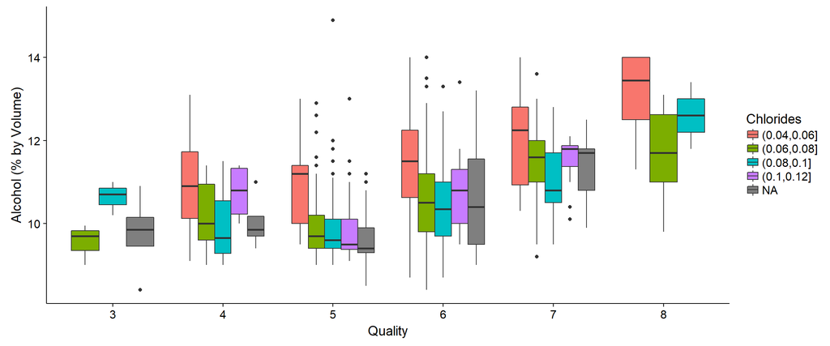

We can almost see a negative correlation between chlorides and alcohol / quality, but the factor level of .1-.12 is a little off when describing the system as a whole. If we were to ignore that level of chlorides, then there would be a clear relationship between the three variables.

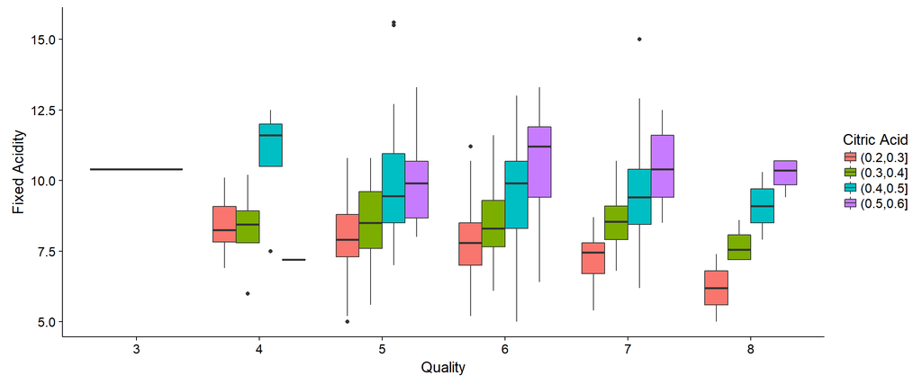

After finding out more about fixed acidity and citric acid, there seemed to be a clear anecdotal relationship between the two (as they both contribute to a tart flavor). That relationship can be clearly shown here, where citric acidity is positively correlated with fixed acidity and fixed acidity is positively correlated with quality.

```
##
## Calls:
## m1: lm(formula = quality ~ alcohol, data = dfWine)
## m2: lm(formula = quality ~ alcohol + volatile.acidity, data = dfWine)
## m3: lm(formula = quality ~ alcohol + volatile.acidity + fixed.acidity,
##     data = dfWine)
## m4: lm(formula = quality ~ alcohol + volatile.acidity + fixed.acidity +
##     total.sulfur.dioxide, data = dfWine)
## m5: lm(formula = quality ~ alcohol + volatile.acidity + fixed.acidity +
##     total.sulfur.dioxide + citricDisc, data = dfWine)
## m6: lm(formula = quality ~ alcohol + volatile.acidity + fixed.acidity +
##     total.sulfur.dioxide + citricDisc + citric.acid, data = dfWine)
##
## =====================================================================================================
##                                       m1         m2         m3         m4         m5         m6
## -----------------------------------------------------------------------------------------------------
##   (Intercept)                       1.875***   3.095***   2.674***   2.912***   2.693***   3.131***
##                                    (0.175)    (0.184)    (0.218)    (0.228)    (0.313)    (0.348)
##   alcohol                           0.361***   0.314***   0.321***   0.309***   0.332***   0.337***
##                                    (0.017)    (0.016)    (0.016)    (0.016)    (0.023)    (0.023)
##   volatile.acidity                            -1.384***  -1.286***  -1.286***  -1.133***  -1.191***
##                                               (0.095)    (0.099)    (0.098)    (0.157)    (0.158)
##   fixed.acidity                                           0.036***   0.032**    0.023      0.031
##                                                          (0.010)    (0.010)    (0.016)    (0.016)
##   total.sulfur.dioxide                                              -0.002***  -0.003***  -0.003***
##                                                                     (0.001)    (0.001)    (0.001)
##   citricDisc: (0.3,0.4]/(0.2,0.3]                                               0.100      0.296**
##                                                                                (0.060)    (0.092)
##   citricDisc: (0.4,0.5]/(0.2,0.3]                                              -0.044      0.367*
##                                                                                (0.067)    (0.161)
##   citricDisc: (0.5,0.6]/(0.2,0.3]                                               0.081      0.670**
##                                                                                (0.085)    (0.226)
##   citric.acid                                                                             -2.080**
##                                                                                           (0.740)
## -----------------------------------------------------------------------------------------------------
##   R-squared                             0.2        0.3        0.3        0.3       0.4        0.4
##   adj. R-squared                        0.2        0.3        0.3        0.3       0.4        0.4
##   sigma                                 0.7        0.7        0.7        0.7       0.6        0.6
##   F                                   468.3      370.4      253.1      193.9      78.2       70.0
##   p                                     0.0        0.0        0.0        0.0       0.0        0.0
##   Log-likelihood                    -1721.1    -1621.8    -1615.4    -1609.6    -851.4     -847.4
##   Deviance                            805.9      711.8      706.1      701.0     353.1      349.9
##   AIC                                3448.1     3251.6     3240.8     3231.3    1720.8     1714.9
##   BIC                                3464.2     3273.1     3267.6     3263.6    1764.0     1762.8
##   N                                  1599       1599       1599       1599       890        890
## =====================================================================================================
```

### Talk about some of the relationships you observed in this part of the investigation. Were there features that strengthened each other in terms of looking at your feature(s) of interest?

There weren’t that many factors that were highly related to each other when compared with quality, other than citric acid and fixed acidity, which was a bit of a let down. It seems that the other factors were not as highly interrelated with each other as I thought, or perhaps there was a certain graph that I missed that would have elucidated the relationship between these features.

### Were there any interesting or surprising interactions between features?

The fact that there were such little relationships between variables was interesting in and of itself. Volatile acidity, citric acidity, fixed acidity, and total sulfur dioxide all didn’t have that high of correlation with both quality and alcohol.

## Final Plots

### Plot 1

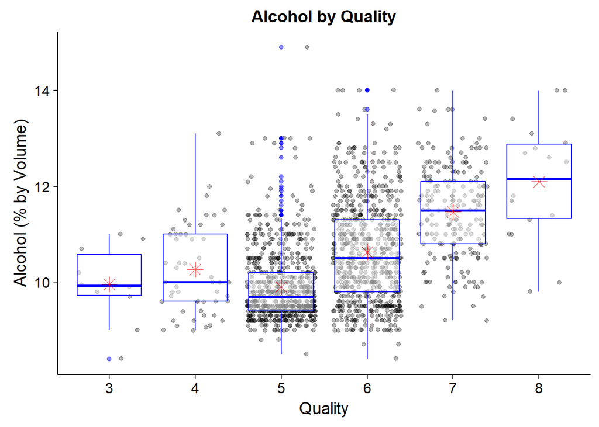

The alcohol level by volume has a high positive correlation with the quality of the wine from the quality values of 5-8. The majority of the quality values are in 5-7, so having 8 be positively correlated as well is just icing on the cake for this correlation of 0.5 between alcohol by volume and quality.

### Plot 2

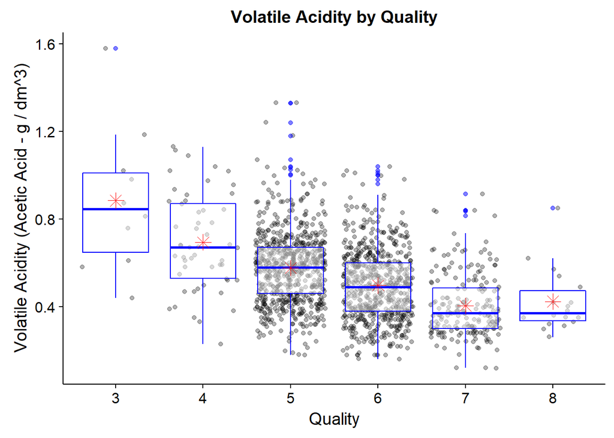

Acetic acid is negatively correlated with quality across the values of quality as deemed by wine experts. Voaltile acidity is what makes wine taste more like vinegar, which is a possible reason why having more volatile acid is correlated with a drop in quality. Wine experts possibly have refined tastes to be able to detect if a wine tastes more or less like vinegar.

### Plot 3

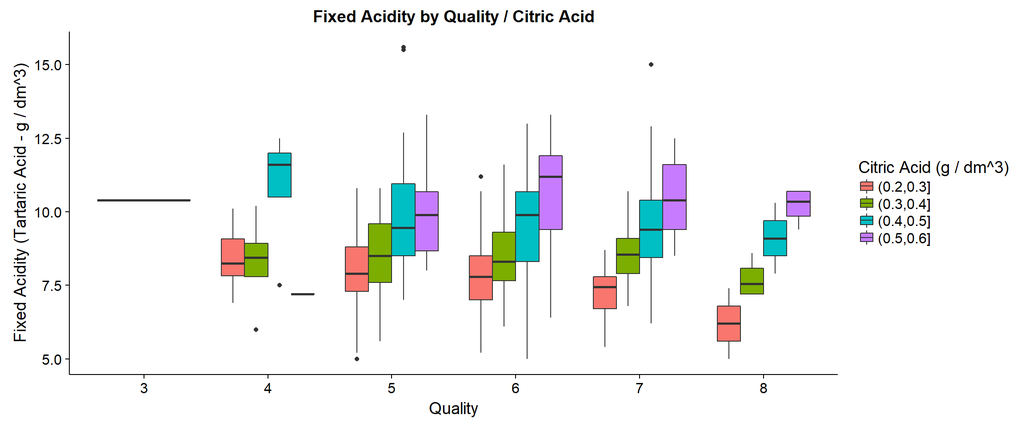

## Reflection

Across the dataset there are many different variables that could effect the quality of red wine via the ratings of experts. After digging a little deeper, there seems to be high positive correlations between quality of red wine and alcohol level, low positive correlation between red wine and citric acid, high negative correlation between red wine and volatile acid, and low negative correlation between red wine and chlorides.

After doing a deeper analysis on all of the above mentioned variables, we can actually see that alcohol seems to have the strongest positive correlation and volatile acid has the strongest negative correlation on red wines than the other variables, whereas the other variables do not have a strong statistically significant effect on the quality of red wines. This is supported by the multivariate graphs towards the end which do not show a strong relationship between quality / alcohol level and the third variable(s), where quality and alcohol are two of the most highly related variables in this dataset.

One thing that could be added to make the analysis stronger would be to implement a support vector machine to create tighter boundaries across variables and make the modeling more robust. There is still a suitable amount of error term in the model so far, and the creators of the dataset mentioned that they used SVM’s to improve their own analysis.